# Proportion of county in poor health

This is the response variable we will be examining in this presentation. What variables help predict poor health?

Data is from [countyhealthrankings.org](https://www.countyhealthrankings.org/).

# Key Questions

1. Which of the x variables are the most important predictors for poor health status?
   - Which x variables does the tree-building algorithm choose to partition the most homogenous outcome groups?
2. Are there any x variables we thought would be good predictors but are not actually?
   - For example, due to collinearity with another x variable?
3. What interesting correlations between the predictor variables can we find?

## First, let's review of the distribution of poor health status.

```python
print("The mean proportion of poor health on the county-level is ",
      county_data["Poor.Health"].mean())
print("The median proportion of poor health on the county-level is ",
      county_data["Poor.Health"].median())
print("The quantiles proportion of poor health on the county-level are: \n",
      county_data["Poor.Health"].quantile([.0, .25, .5, .75, 1.0]))
```

```
The mean proportion of poor health on the county-level is  0.17438471454880308
The median proportion of poor health on the county-level is  0.1673
The quantiles proportion of poor health on the county-level are:
 0.00    0.08290
0.25    0.14035
0.50    0.16730
0.75    0.20395
1.00    0.40730
Name: Poor.Health, dtype: float64
```

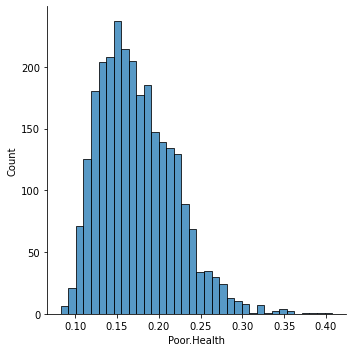

```python
sns.displot(county_data['Poor.Health']);
```

The distribution of poor health also seems to be right skewed. Its skewness seems to explain why the mean is higher than the median proportion of poor health.

## Next, let's look at this data on the state-wide level

- Are there some states with worse health outcomes than others?
- Is there a geographical trend of better or worse health?

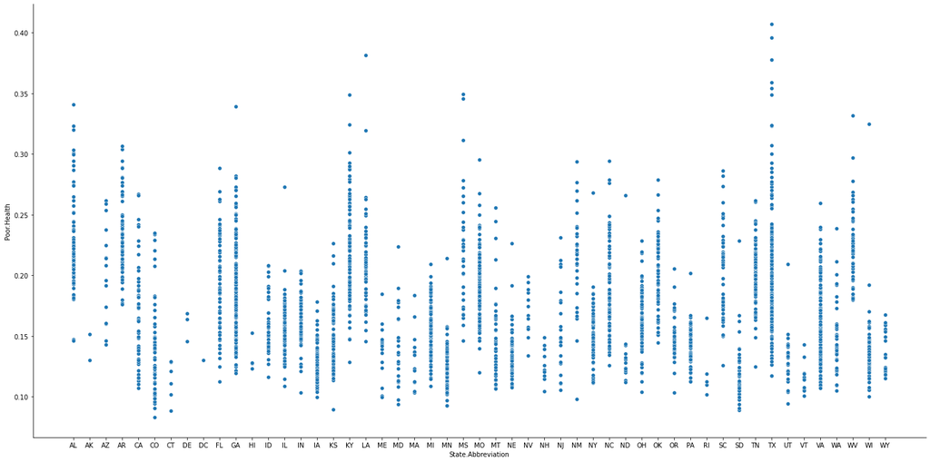

```python
state_means = county_data.groupby('State.Abbreviation').mean()
state_poor_health_point = sns.relplot(x='State.Abbreviation', y='Poor.Health', data=county_data,
                   height=10, aspect=2,);
```

Texas and Louisiana seem to have the two counties with the highest proportion of poor health. Alabama, Georgia, Kentucky, and Mississippi also have counties with high proportions of poor health. This is not a formal analysis (only a visual analysis of the counties with the highest proportions of poor health), but these states all have the common denominator of being part of the South.

## Another, perhaps more easily read visualization of mean poor health for each state:

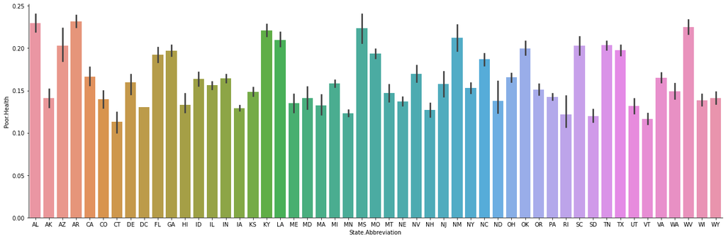

```python
state_poor_health_bar = sns.catplot(data=county_data, y='Poor.Health', x='State.Abbreviation',
                                    height=6, aspect=3, kind='bar');
```

```python
state_means.sort_values(by='Poor.Health', inplace=True)
print('The states with the lowest proportion of poor heath are:')
print(state_means['Poor.Health'].head(5))
print('\n')
print('The states with the highest proportion of poor heath are:')
print(state_means['Poor.Health'].tail(5))
```

```
The states with the lowest proportion of poor heath are:
State.Abbreviation
CT    0.113317
VT    0.116242
SD    0.119667
RI    0.121780
MN    0.123187
Name: Poor.Health, dtype: float64


The states with the highest proportion of poor heath are:
State.Abbreviation
KY    0.221119
MS    0.223572
WV    0.225047
AL    0.229694
AR    0.231626
Name: Poor.Health, dtype: float64
```

The states with the lowest proportion of poor health all seem to be located throughout the northern part of the continental US. The states with the highest proportion of poor health all seem to be located throughout the southeastern quarter of the US.

# Potential Predictor Variables

I think proportion of poor health might be associated with these characteristics of predictor variables available in our data set:

- (high proportion of) uninsured
- (low number of) primary care physicians per 1000
- (high proportion of) adult obesity
- (high proportion of) smokers
- (low proportion of) high school graduation
- (high proportion of) physical inactivity
- (high proportion of) excessive drinking
- (low) median household income
- (high proportion of) severe housing problems
- (low) life expectancy

### Vizualizing what I think might be one of the stronger predictors:

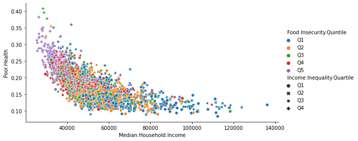

```python
sns.relplot(x='Median.Household.Income' , y='Poor.Health', data=county_data, height=4, aspect=2, hue='Food.Insecurity.Quintile', style='Income.Inequality.Quartile');
```

Median household income has a strong, negative, non-linear relationship with poor health.

The blue data points (lowest food insecurity) seem to be clustered at around lower poor health levels compared to other quintiles, even if they have varying median household income. Similarly, the purple data points (highest food insecurity) seem to be clustered at higher proportions of poor health. The counties with the poorest health also seem to be those in the highest income inequality quartile, represented by + markers.

### I will now look at the correlations between the predictor variables and proportion of poor health.

```python
varlist=county_data[['Poor.Health','Uninsured', 'Primary.Care.Physicians.Per.1000', 'Mental.health.providers.Per.1000', 'Adult.Obesity', 'Proportion.of.Smokers', 'High.School.Graduation', 'Insufficient.Sleep', 'Physical.Inactivity', 'Excessive.Drinking', 'Median.Household.Income', 'Severe.Housing.Problems', 'Unemployment', 'Percent.Rural', 'Over.65', 'Percent.Females', 'Life.Expectancy', 'Population']]
correlation = varlist.corr()['Poor.Health']
correlation.drop(index=correlation.index[0], axis=0, inplace=True)
corr_strength = pd.cut(correlation, 5, labels=['r<0', 'r<0 (weak)', 'r≈0', 'r>0 (weak)', 'r>0'])
dfcorr = pd.concat([correlation, corr_strength], axis=1)
dfcorr=dfcorr.reset_index()
dfcorr.columns=['predictor variables', 'correlation', 'corr_strength']
print(dfcorr)
```

```
                 predictor variables  correlation corr_strength
0                          Uninsured     0.453265           r>0
1   Primary.Care.Physicians.Per.1000    -0.306522    r<0 (weak)
2   Mental.health.providers.Per.1000    -0.098010           r≈0
3                      Adult.Obesity     0.456427           r>0
4              Proportion.of.Smokers     0.723864           r>0
5             High.School.Graduation    -0.110337           r≈0
6                 Insufficient.Sleep     0.652547           r>0
7                Physical.Inactivity     0.603145           r>0
8                 Excessive.Drinking    -0.660582           r<0
9            Median.Household.Income    -0.680146           r<0
10           Severe.Housing.Problems     0.280768    r>0 (weak)
11                      Unemployment     0.544357           r>0
12                     Percent.Rural     0.124330           r≈0
13                           Over.65    -0.104271           r≈0
14                   Percent.Females    -0.008175           r≈0
15                   Life.Expectancy    -0.644491           r<0
16                        Population    -0.081542           r≈0
```

### A graph of these correlations and their strengths:

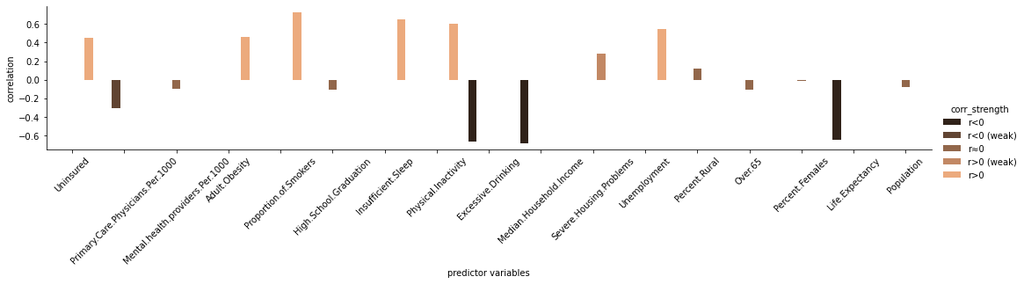

```python
corrplot = sns.catplot(x='predictor variables', data=dfcorr, y='correlation', height=3, aspect=5, kind='bar', hue='corr_strength', palette = 'copper');
corrplot.set_xticklabels(rotation=45)
pass
```

I expect variables with strong correlation like proportion of smokers and life expectancy to be some of the most important variables to predict poor health.

Next, I would like to use regression lines and residual plots to check the quality of some of the weak correlations.

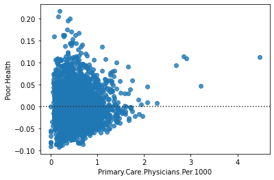

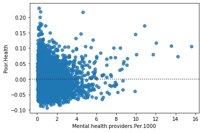

```python
for xvar in xweaklist:
    plt.show()
    sns.residplot(x=xvar, y="Poor.Health", data=county_data)
```

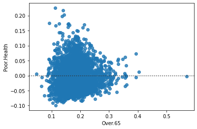

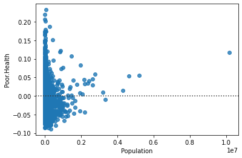

```python
for xvar in xweaklist2:
    plt.show()
    sns.residplot(x=xvar, y="Poor.Health", data=county_data)
```

Except for the proportion of people over 65, the residual plots all seem to exhibit extreme heteroskedasticity. This means that the residuals get larger or smaller as we are trying to make predictions for larger and larger predictive variable values. Heteroskedasticity means that the quality of correlation is not ideal.

I thus expect the number of primary care physicians per 1000, mental health providers per 1000, and population to not be good predictors of poor health.

# Predictor Variable Relationships

We will now investigate some interesting relationships between predictor variables.

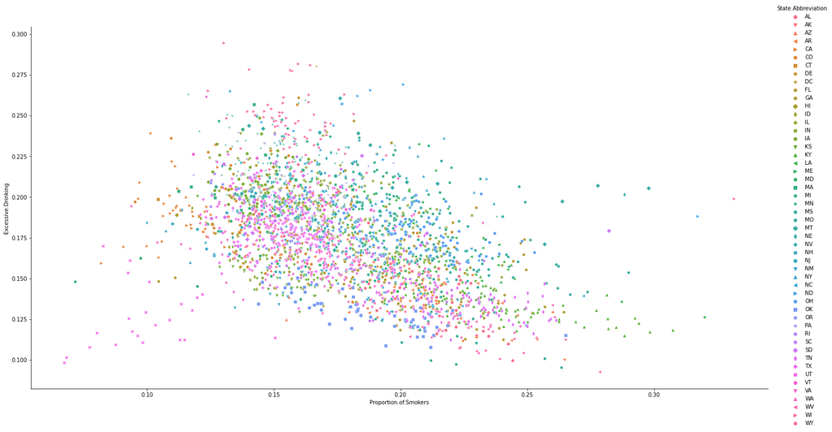

```python
plot1 = sns.relplot(x='Proportion.of.Smokers', y='Excessive.Drinking', data=county_data,
                    hue="State.Abbreviation", style="State.Abbreviation", height=10, aspect=2,
                    markers=state_markers);
```

Excessive drinking is negatively correlated with proportion of smokers on the county level; I would've thought these two unhealthy activities were positively correlated with each other. For example, I was thinking that someone who is addicted to smoking might also be predisposed to have an alcohol addiction.

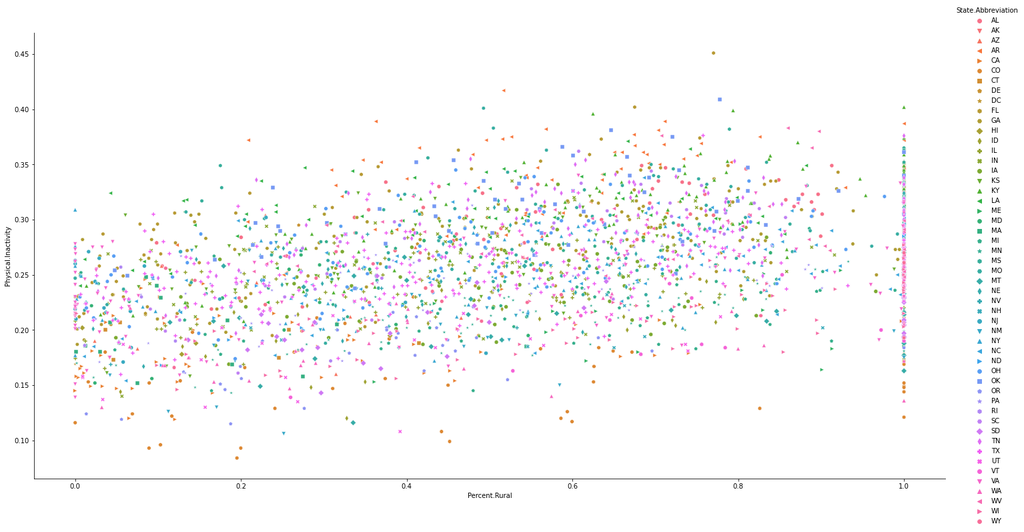

```python
plot2 = sns.relplot(x='Percent.Rural', y='Physical.Inactivity', data=county_data,
                    hue="State.Abbreviation", style="State.Abbreviation", height=10, aspect=2,
                    markers=state_markers);
```

Percent rural is mildly positively correlated with physical inactivity; I expected that rural folk would walk more to travel. However, a reason for this positive correlation is that rural residents have to drive from place to place more, versus people who live in cities have to walk to nearby destinations or walk to public transportation.

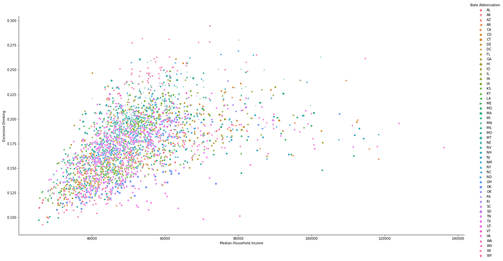

```python
plot3 = sns.relplot(x='Median.Household.Income', y='Excessive.Drinking', data=county_data,
                    hue="State.Abbreviation", style="State.Abbreviation", height=10, aspect=2,
                    markers=state_markers);
```

Excessive drinking is positively correlated with median household income but negatively correlated with poor health. Because excessive drinking is collinear with median household income, excessive drinking by itself cannot accurately predict proportion of poor health without median household income information.

# A simple tree to predict proportion of poor health

I'll set the maximum number of leaf nodes to 10. Setting a maximum number of leaf nodes will sacrifice predictive power for increased interpretability of the model.

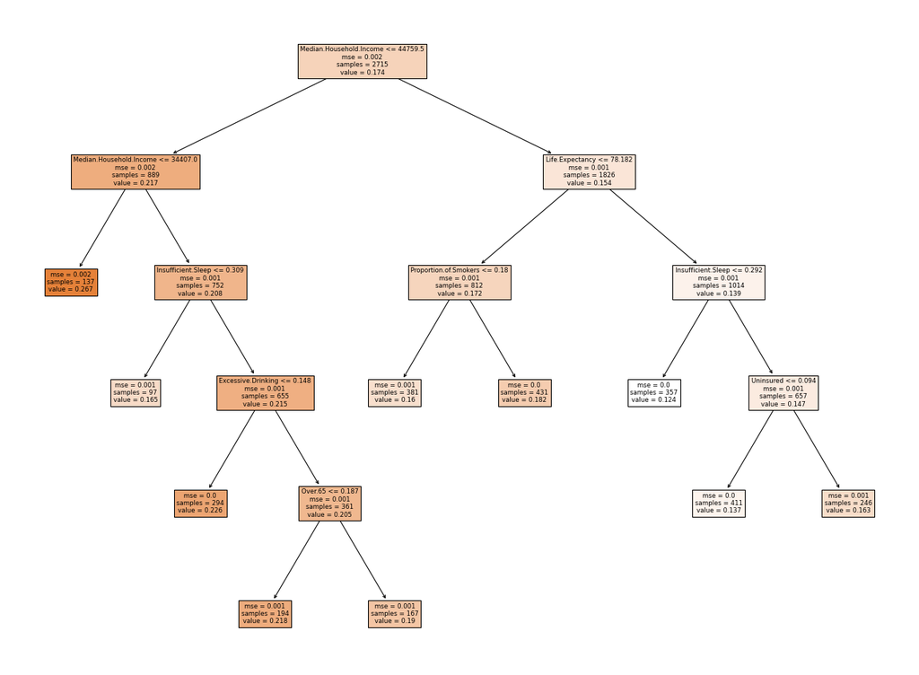

```python
fig = plt.figure(num=None, figsize=(20, 15), dpi=80, facecolor='w', edgecolor='k')
tree.plot_tree(regtree, filled=True, feature_names=X.columns);
pass
```

The counties with highest proportion of poor health are the most economically disadvantaged counties.

- The counties with the highest proportion of poor health are those that have not only a median income of less than or equal to 44,759.5 (the first node), but also less than or equal to 34,407 (the second node).

Meanwhile, the counties with the lowest proportion of poor health seem to have a relatively greater median income, have a long life expectancy, and get enough sleep.

- The counties with the lowest proportion of poor health are those that have a median income of greater than 44,759.5 (the first node), a life expectancy of greater than 78.182 years (the second node), and have a proportion of insufficient sleep of less than 0.292.

```python
train_scores = regtree.score(X_train, y_train)
test_scores = regtree.score(X_test, y_test)

print('The R-squared of this tree on the training data is ', train_scores, '.')
print('The R-squared of this tree on the test data is ', test_scores, '.')
```

```
The R-squared of this tree on the training data is  0.7142491335488956 .
The R-squared of this tree on the test data is  0.7268349441653824 .
```

71.42% of the variability in poor health in the training data set is explained by the predictor variables found in the tree.

72.68% of the variability in poor health in the test data set is explained by the predictor variables found in the tree.

Because the R-squared of the training data is not significantly higher than that of the test data, this tree has not been overfit. If the tree were overfit, we would get a much more optimistic R-squared for the training data than the test data.

```python
importances = pd.DataFrame({'Feature':X_train.columns,'Importance':np.round(regtree.feature_importances_,3)})
importances = importances.sort_values('Importance',ascending=False)
print(importances[:10])
```

```
                          Feature  Importance
9         Median.Household.Income       0.710
15                Life.Expectancy       0.122
6              Insufficient.Sleep       0.082
0                       Uninsured       0.026
4           Proportion.of.Smokers       0.024
8              Excessive.Drinking       0.018
13                        Over.65       0.018
7             Physical.Inactivity       0.000
17  Income.Inequality.Quartile_Q1       0.000
24    Food.Insecurity.Quintile_Q4       0.000
```

These importances are calculated as the Gini importance, or mean decrease in impurity of poor health in each node.

As expected, median household income is by far the most important predictor of poor health. Life expectancy is also unsurprisingly an important predictor. What surprised me the most was insufficient sleep as the third most important predictor, which now makes me wonder how important sleep is as a predictor of health for individuals rather than on the county level.

Another surprise to me was the relative lack of importance of physical inactivity and adult obesity as predictor variables. Next, we will parse whether this might be due to collinearity between these variables and the top 3 most important variables.

```python
collinearity = county_data[['Median.Household.Income', 'Life.Expectancy', 'Insufficient.Sleep', 'Physical.Inactivity', 'Adult.Obesity']]
picorr=collinearity.corr()['Physical.Inactivity']
picorr.drop(labels=['Physical.Inactivity', 'Adult.Obesity'], inplace=True)
aocorr=collinearity.corr()['Adult.Obesity']
aocorr.drop(labels=['Physical.Inactivity', 'Adult.Obesity'], inplace=True)
print('collinearities for physical inactivity versus:', '\n', picorr, '\n', '\n', 'collinearities for adult obesity versus:', '\n', aocorr)
```

```
collinearities for physical inactivity versus:
 Median.Household.Income   -0.584481
Life.Expectancy           -0.674575
Insufficient.Sleep         0.504025
Name: Physical.Inactivity, dtype: float64

 collinearities for adult obesity versus:
 Median.Household.Income   -0.473422
Life.Expectancy           -0.571843
Insufficient.Sleep         0.446421
Name: Adult.Obesity, dtype: float64
```

There is not as much collinearity as I might have expected between median household income, life expectancy, and insufficient sleep versus physical inactivity and adult obesity. The only very collinear variables I think would be the correlation between life expectancy and physical inactivity, at r=-0.67. Maybe physical inactivity is not listed as an important variable because it is collinear with life expectancy; the information physical inactivity can provide to predict poor health is already provided by life expectancy.

The lack of collinearity between the most important variables and the other variables I thought should also be important indicate that maybe these variables simply are not as important as I thought they would be, rather than because of a collinearity issue.

# Conclusions

1. Which of the x variables are the most important predictors for poor health status?
   - The most important predictor is by far median household income. Other important predictors include life expectancy and insufficient sleep. Less important predictors include proportion of uninsured, smokers, and excessive drinking.
2. Are there any x variables we thought would be good predictors but are not actually?
   - Yes; I thought adult obesity would be an important predictor of proportion of poor health, but it is actually relatively not important. Physical inactivity is also not an important predictor, but that could just be because it is too collinear with life expectancy.
3. What interesting correlations between the predictor variables can we find?
   - Relationships I found interesting were the negative correlation between excessive drinking and proportion of smokers, the positive correlation between physical inactivity and percent rural, and the positive correlation between excessive drinking and median household income.

## Suggestions for further research

1. Get data for other possible predictor variables such as proportion living with families larger than 3, climate type, number of fast food restaurants per 1000, etc.
   - Are these important in predicting poor health? I'm especially interested in climate type, since I noticed many of the lower proportion of poor health counties were located in the northern US.
2. Get this data from 100 years ago.
   - Has the importance of predictors changed over time?
3. Research successful initiatives to decrease proportion of poor health.
   - This would probably entail less statistical analysis and reading more case studies.
4. Research why exactly median household income is the most important predictor of poor health.
   - What do counties with higher median income do differently to keep their residents healthy? Variation in proportion of poor health in counties with low median household income can also be explored.